# DraftB

[figure not shown]

## Project Demonstration Notebook

Project Group Number: Project Group 9  
Student Names: Aishwarya Phanse, Zheming Chen, Yaqian Zhang

## Introduction

In 1996, Nintendo released the first pokemon game: Red & Blue. Ever since then, pokemon became one of the most successful and best-selling games ever.

This year, the new pokemon game: Sword & Shield is coming. After over 20 years, does this 'childish' game still have the magic to attract new players?

Like any other old games, pokemon now is facing a problem:  
7 generations, 18 different types, over 800 pokemons and 700 different moves, this massive data can easily drown the new players and chase them away.

In this project, we will find insights and simplify this data for new players, and finally, help them to select pokemons to maximize their chances of winning basis both the pokemons' characteristics.

## Executive Summary

#### Project Objective

Provide pokemon players with meaningful data regarding attributes of pokemons to help them take calculated decision of choosing a pokemon so as to win the battle.

#### Project Roadmap

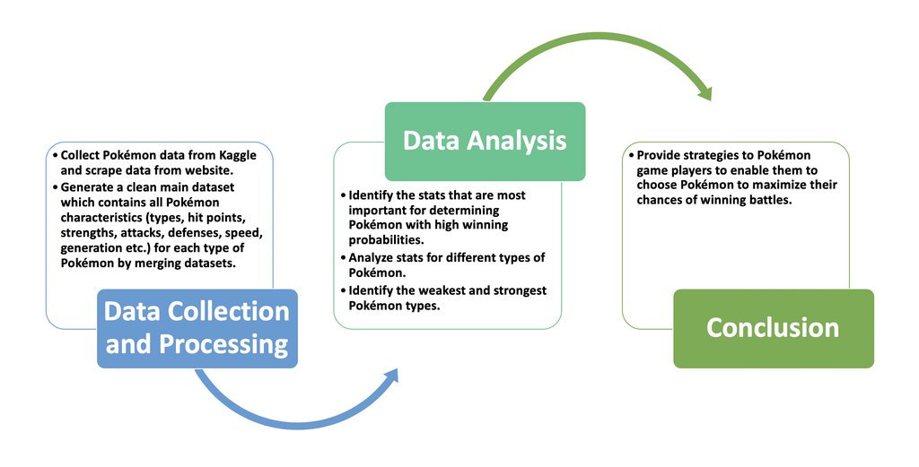

1. Generate a clean main dataset which contains all pokemon characteritics (types, hit points, strengths, attacks, defenses, speed, generation etc.) for each type of Pokémon.
2. Based on analysis conducted (visualize the distribution for each attribute, learn the relationship between the Pokemon's characteristic features(X variables) and whether the Pokemon would win the game (Y variable)) to draft strategies for Pokémon game players.
3. Simulate games using the draft strategies, and validate that by comparing with baseline, and this period would be iterative (If the result is positive, we will mark that draft strategy as useful strategy; but if the result is negative, we will go back to phase two). Third phase's objective is to select useful strategies for Pokémon game players.
4. Objective is to provide clear insights based on the strategies.

## PHASE 1: Data Collection + Data Processing

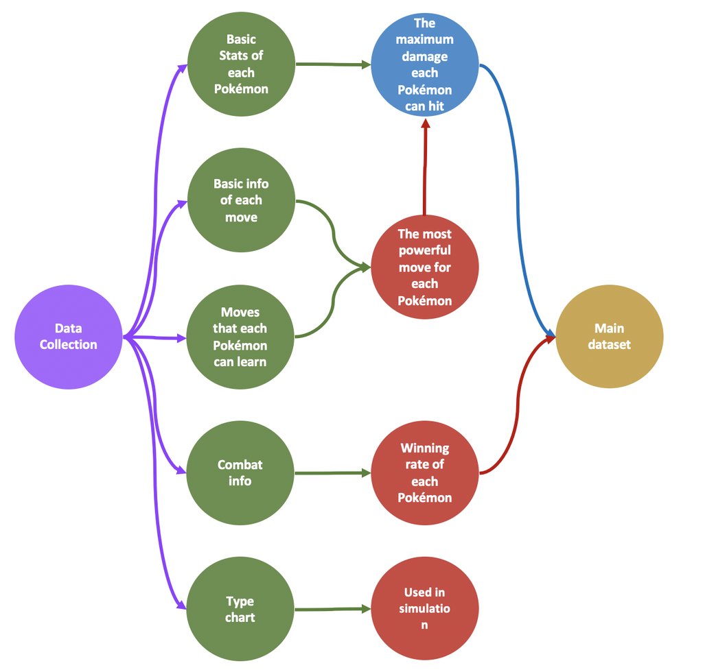

##### There are 5 datasets that we considered from varied sources for our analysis. Below is a description of the datasets:

##### - Pokemon attributes from Pokemon.csv file from Kaggle.

The variables include:  
Index number: Each pokemon has a special distinct index number.  
Name: The name of pokemon.  
Type: Pokemon's type(fire/water...). Some pokemons have two types while others have only one.  
HP: Hit points. When the hp is zero, the pokemon has to retreat.  
Attack: Attack points. When the pokemon use a physical move, the damage is calculated based on attack points.  
Defense: Defense points. When the pokemon is attacked by a physical move, the damage is calculated based on Defense.  
Sp. Atk: Special Attack points. When the pokemon use a Special move, the damage is calculated based on Special attack points.  
Sp. Def: Special defense points. When the pokemon is attacked by a special move, the damage is calculated based on Special Defense.  
Speed: Speed. The pokemon who has higher speed can attack first.  
Generation: Generation the pokemon first appeared in the game.  
Legendary: If the pokemon is a legendary pokemon.

##### - Moves data scraped from pokemon website.

The variables include:  
No.: The index number of the move.  
Name: The name of the move.  
Type: The type of the move.  
Damage: The kind of damage the move causes.(Physical/Special/Status)  
Power: The basic power of the move.  
Accuracy: The accuracy of the move.  
PP: The times a pokemon can use this move.

##### - Moves each pokemon can learn scraped from pokemon website.

Different pokemon can learn different moves.  
The variable include: Moves: The name of the move.

##### - Combats from combats.csv file from Kaggle.

The outcome of battles.  
The variables include: First_pokemon: The first pokemon's index number.  
Second_pokemon: The second pokemon's index number.  
Winner: The winning pokmeon's index number.

##### - Type chart.

Different types of pokemons have different weaknesses.  
This data set is only going to be used during simulation.

```python
import numpy as np
import pandas as pd
import matplotlib.mlab as mlab
import matplotlib.pyplot as plt
import seaborn as sns
import random
import cv2
import statsmodels.api as sm
from sklearn.preprocessing import StandardScaler
from sklearn.cluster import KMeans
import warnings
warnings.filterwarnings("ignore", category=FutureWarning)
random.seed(888)
```

##### We started with importing the basic and most important dataset named Pokemon.csv which comprised all pokemon attributes. Then we explored the dataset to clean it for analysis.

##### Preliminary cleaning involved:

- Rename first column to indicate Index Number
- Find null values in the dataset and replace with appropriate values.

```python
pokemon = pd.read_csv("pokemon/pokemon.csv")
pokemon = pokemon.rename(index=str, columns={"#": "Number"})
```

```python
pokemon.head()
```

|  | Number | Name | Type 1 | Type 2 | HP | Attack | Defense | Sp. Atk | Sp. Def | Speed | Generation | Legendary |
| --- | --- | --- | --- | --- | --- | --- | --- | --- | --- | --- | --- | --- |
| 0 | 1 | Bulbasaur | Grass | Poison | 45 | 49 | 49 | 65 | 65 | 45 | 1 | False |
| 1 | 2 | Ivysaur | Grass | Poison | 60 | 62 | 63 | 80 | 80 | 60 | 1 | False |
| 2 | 3 | Venusaur | Grass | Poison | 80 | 82 | 83 | 100 | 100 | 80 | 1 | False |
| 3 | 4 | Mega Venusaur | Grass | Poison | 80 | 100 | 123 | 122 | 120 | 80 | 1 | False |
| 4 | 5 | Charmander | Fire | NaN | 39 | 52 | 43 | 60 | 50 | 65 | 1 | False |

```python
pokemon.isnull().sum()
```

```
Number          0
Name            1
Type 1          0
Type 2        386
HP              0
Attack          0
Defense         0
Sp. Atk         0
Sp. Def         0
Speed           0
Generation      0
Legendary       0
dtype: int64
```

##### - Some pokemon only have one type. Hence, the missing values in Type 2 is acceptable.

##### - One of the pokemons name is missing. We find the name using the Index number in the other datasets we have used and replace it in the dataframe here.

```python
pokemon[pokemon['Name'].isnull()]
```

|  | Number | Name | Type 1 | Type 2 | HP | Attack | Defense | Sp. Atk | Sp. Def | Speed | Generation | Legendary |
| --- | --- | --- | --- | --- | --- | --- | --- | --- | --- | --- | --- | --- |
| 62 | 63 | NaN | Fighting | NaN | 65 | 105 | 60 | 60 | 70 | 95 | 1 | False |

##### According to the Number of the pokemon, and get the missing value: Primeape

```python
pokemon.loc[pokemon['Name'].isnull(),'Name']='Primeape'
```

```python
pokemon[pokemon['Number']==63]
```

|  | Number | Name | Type 1 | Type 2 | HP | Attack | Defense | Sp. Atk | Sp. Def | Speed | Generation | Legendary |
| --- | --- | --- | --- | --- | --- | --- | --- | --- | --- | --- | --- | --- |
| 62 | 63 | Primeape | Fighting | NaN | 65 | 105 | 60 | 60 | 70 | 95 | 1 | False |

##### Create a new columns called 'stats_sum' to represent the sum of HP, Atk, Def, Sp.Atk, Sp.Def and Speed.

```python
pokemon["stats_sum"] = pokemon["HP"] + pokemon["Attack"] + pokemon["Defense"] + pokemon["Sp. Atk"] + pokemon["Sp. Def"] + pokemon["Speed"]
```

```python
pokemon.head()
```

|  | Number | Name | Type 1 | Type 2 | HP | Attack | Defense | Sp. Atk | Sp. Def | Speed | Generation | Legendary | stats_sum |
| --- | --- | --- | --- | --- | --- | --- | --- | --- | --- | --- | --- | --- | --- |
| 0 | 1 | Bulbasaur | Grass | Poison | 45 | 49 | 49 | 65 | 65 | 45 | 1 | False | 318 |
| 1 | 2 | Ivysaur | Grass | Poison | 60 | 62 | 63 | 80 | 80 | 60 | 1 | False | 405 |
| 2 | 3 | Venusaur | Grass | Poison | 80 | 82 | 83 | 100 | 100 | 80 | 1 | False | 525 |
| 3 | 4 | Mega Venusaur | Grass | Poison | 80 | 100 | 123 | 122 | 120 | 80 | 1 | False | 625 |
| 4 | 5 | Charmander | Fire | NaN | 39 | 52 | 43 | 60 | 50 | 65 | 1 | False | 309 |

##### Loading the information of each move. This dataset is scraped from website.

Now we scrape all the moves data from the website that includes the Status, Physical Power and Special Power of all pokemons.

```python
#Now we need the all the moves' detail information
import requests
import lxml.html as lh
import pandas as pd

url='https://bulbapedia.bulbagarden.net/wiki/List_of_moves'
page = requests.get(url)
doc = lh.fromstring(page.content)
tr_elements = doc.xpath('//tr')

#Check the length of the first 12 rows
[len(T) for T in tr_elements[:12]]

#Create empty list
col=[]
i=0
#For each row, store each first element (header) and an empty list
for t in tr_elements[1]:
    i+=1
    name=t.text_content().replace('\n', '').replace(' ', '')
    # print ('%d:"%s"'%(i,name))
    col.append((name,[]))

#Since out first row is the header, data is stored on the second row onwards
for j in range(1,len(tr_elements)):
    #T is our j'th row
    T=tr_elements[j]

    #If row is not of size 6, the //tr data is not from our table
    if len(T)!=9:
        break

    #i is the index of our column
    i=0

    #Iterate through each element of the row
    for t in T.iterchildren():
        data=t.text_content().replace('\n', '').replace('*', '')
        #Check if row is empty
        if i>0:
        #Convert any numerical value to integers
            try:
                data=int(data)
            except:
                pass
        #Append the data to the empty list of the i'th column
        col[i][1].append(data)
        #Increment i for the next column
        i+=1

Dict={title:column for (title,column) in col}
df=pd.DataFrame(Dict)
df = df[['#', 'Name', 'Type', 'Category', 'Contest', 'PP', 'Power', 'Accuracy', 'Gen']]
df.head()
```

|  | # | Name | Type | Category | Contest | PP | Power | Accuracy | Gen |
| --- | --- | --- | --- | --- | --- | --- | --- | --- | --- |
| 0 | # | Name | Type | Category | Contest | PP | Power | Accuracy | Gen |
| 1 | 1 | Pound | Normal | Physical | Tough | 35 | 40 | 100% | I |
| 2 | 2 | Karate Chop | Fighting | Physical | Tough | 25 | 50 | 100% | I |
| 3 | 3 | Double Slap | Normal | Physical | Cute | 10 | 15 | 85% | I |
| 4 | 4 | Comet Punch | Normal | Physical | Tough | 15 | 18 | 85% | I |

##### Data processing:

1. Drop first row
2. Drop column ['#']
3. Drop rows whose 'PP' is only 1. Those moves are Z-moves, and is the same for every pokemon.
4. Change '-' under Power column to 0, since those are status category moves, and don't have any damage.
5. Change '-' under Accuracy to 200%, since that means the move will always hit the target.
6. Change the type of columns ['Accuracy','Power'] to int.
7. Calculate the estmated power of each move.

```python
df = df.drop(columns = ['#', 'Contest', 'Gen'])
df = df.drop([0])
df = df[df['PP'] != 1]
df.head()

df.loc[df['Power'] == '—', 'Power'] = '0'
df.loc[df['Power'] == '', 'Power'] = '0'
df.loc[df['Power'].isnull(), 'Power'] = '0'
#if the accuracy is '-', it means that this moves will always hit the target. So we change the accuracy to 200%
df.loc[df['Accuracy'] == '—', 'Accuracy'] = '200'
df.loc[df['Accuracy'] == '— ', 'Accuracy'] = '200'
df['Accuracy'] = df['Accuracy'].str.rstrip('%').astype('float') / 100.0

df.index = range(1, len(df)+1)

df['Power'] = df['Power'].astype(int)
df['Accuracy'] = df['Accuracy'].astype(float)
df['estPower'] = 0
for i in range(1, len(df)+1):
    if df['Accuracy'][i] == 2:
        df.loc[i, 'estPower'] = df['Power'][i]
    else:
        df.loc[i, 'estPower'] = df['Power'][i] * df['Accuracy'][i]
df.head()
```

|  | Name | Type | Category | PP | Power | Accuracy | estPower |
| --- | --- | --- | --- | --- | --- | --- | --- |
| 1 | Pound | Normal | Physical | 35 | 40 | 1.00 | 40.00 |
| 2 | Karate Chop | Fighting | Physical | 25 | 50 | 1.00 | 50.00 |
| 3 | Double Slap | Normal | Physical | 10 | 15 | 0.85 | 12.75 |
| 4 | Comet Punch | Normal | Physical | 15 | 18 | 0.85 | 15.30 |
| 5 | Mega Punch | Normal | Physical | 20 | 80 | 0.85 | 68.00 |

We add a new column 'estPower'.

```python
df.to_csv('All moves.csv')
```

##### Loading the moves for each pokemon. This dataset is scraped from website.

We scrape the moves data for all the pokemons we have in our primary dataset using urllib2 and BeautifulSoup.  
Each pokemon's move is saved as a csv file.

1. First, we define a function to get pokemon's moves.

```python
import urllib.request as urllib2
import pandas as pd
from bs4 import BeautifulSoup
from string import punctuation
import math

#organize the data, and create a list of pokemon names.
#we use beautiful soup to scrape the data
user_agent = 'Mozilla/5.0 (Windows; U; Windows NT 5.1; en-US; rv:1.9.0.7) Gecko/2009021910 Firefox/3.0.7'
headers={'User-Agent':user_agent,}

#create a list of pokemons that we got the data
ok = []
def getmove(pokelist):
    #create a list of pokemons that we got the data
    global ok
    for i in pokelist:
        url = 'https://pokemondb.net/pokedex/' + i + '/moves/7'
        try:
            request=urllib2.Request(url,None,headers)
            page = urllib2.urlopen(request)
            soup = BeautifulSoup(page, 'html.parser')
            pokemon_move = []
            #LV moves
            lv = soup.find(text = 'Moves learnt by level up')
            try:
                lv = lv.find_next('table')
                for moves in lv.find_all('tr')[1:]:
                    data = moves.find_all('td')
                    move = data[1].text
                    pokemon_move.append(move)
            except:
                pass
            #Egg Moves
            egg = soup.find(text = 'Egg moves')
            try:
                egg = egg.find_next('table')
                for moves in egg.find_all('tr')[1:]:
                    data = moves.find_all('td')
                    move = data[0].text
                    pokemon_move.append(move)
            except:
                pass
            #Move Tutor moves
            tutor = soup.find(text = 'Move Tutor moves')
            try:
                tutor = tutor.find_next('table')
                for moves in tutor.find_all('tr')[1:]:
                    data = moves.find_all('td')
                    move = data[0].text
                    pokemon_move.append(move)
            except:
                pass
        #Moves learnt by TM
            TM = soup.find(text = 'Moves learnt by TM')
            try:
                TM = TM.find_next('table')
                for moves in TM.find_all('tr')[1:]:
                    data = moves.find_all('td')
                    move = data[1].text
                    pokemon_move.append(move)
            except:
                pass
            #Transfer-only moves
            Trans = soup.find(text = 'Transfer-only moves')
            try:
                Trans = Trans.find_next('table')
                for moves in Trans.find_all('tr')[1:]:
                    data = moves.find_all('td')
                    move = data[0].text
                    pokemon_move.append(move)
            except:
                pass
            df = pd.DataFrame(pokemon_move)
            df.columns=['Moves']
            file_name = str(i) + '.csv'
            df.to_csv(file_name, index = False)
            #Append pokemon's name to ok list
            ok.append(str(i))
        except:
            pass
```

```python
getmove(pokemon['Name'])
```

1. Now, we find the pokemons for which we did not find the moves data.

```python
notok=[]
for i in pokemon['Name']:
    if i in ok:
        pass
    else:
        notok.append(i)
notok
```

```
['Mega Venusaur',
 'Mega Charizard X',
 'Mega Charizard Y',
 'Mega Blastoise',
 'Mega Beedrill',
 'Mega Pidgeot',
 'Nidoran♀',
 'Nidoran♂',
 'Mega Alakazam',
 'Mega Slowbro',
 "Farfetch'd",
 'Mega Gengar',
 'Mega Kangaskhan',
 'Mr. Mime',
 'Mega Pinsir',
 'Mega Gyarados',
 'Mega Aerodactyl',
 'Mega Mewtwo X',
 'Mega Mewtwo Y',
 'Mega Ampharos',
 'Mega Steelix',
 'Mega Scizor',
 'Mega Heracross',
 'Mega Houndoom',
 'Mega Tyranitar',
 'Mega Sceptile',
 'Mega Blaziken',
 'Mega Swampert',
 'Mega Gardevoir',
 'Mega Sableye',
 'Mega Mawile',
 'Mega Aggron',
 'Mega Medicham',
 'Mega Manectric',
 'Mega Sharpedo',
 'Mega Camerupt',
 'Mega Altaria',
 'Mega Banette',
 'Mega Absol',
 'Mega Glalie',
```

[output cut: 46 more lines]

```
 'Meowstic Female',
 'Aegislash Blade Forme',
 'Aegislash Shield Forme',
 'Pumpkaboo Average Size',
 'Pumpkaboo Small Size',
 'Pumpkaboo Large Size',
 'Pumpkaboo Super Size',
 'Gourgeist Average Size',
 'Gourgeist Small Size',
 'Gourgeist Large Size',
 'Gourgeist Super Size',
 'Zygarde Half Forme',
 'Mega Diancie',
 'Hoopa Confined',
 'Hoopa Unbound']
```

1. Now, looking at the above list of pokemons, we realize that most of these pokemons are versions of some base pokemons. These will have the same moves as base pokemons. For instance, 'Mega' evolutions will have same moves as of normal pokemons. Also, other versions like Gourgeist Super Size will have same moves as base pokemons like Gourgeist.
- Further we replace any special characters in names.

```python
#organize the data, and create a list of pokemon names.
pokename=[]
for i in notok:
    if '.' in str(i) or 'é' in str(i) or '♀' in str(i) or '♂' in str(i) or '\'' in str(i):
        i = i.replace('.', '-').replace(' ', '').replace('é', 'e').replace('♀', '-f').replace('♂', '-m').replace('\'', '')
        name = str(i).split()[0]
        if name == 'Mega' or name == 'Primal':
            pass
        else:
            pokename.append(name)
    else:
        name = str(i).split()[0]
        if name == 'Mega' or name == 'Primal':
            pass
        else:
            pokename.append(name)
```

```python
getmove(pokename)
```

Check which pokemon are missed again.

```python
notok2=[]
for i in pokename:
    if i in ok:
        pass
    else:
        notok2.append(i)
notok2
```

```
['DeoxysAttack', 'MimeJr-', 'Heat', 'Wash', 'Frost', 'Fan', 'Mow']
```

- Now, we have moves data for all pokemons except 3. We identify the 3 pokemons and scrape the moves dtaa separately for the 3 pokemons.

```python
#rename the pokemons' names
left = ['Mime-Jr', 'Rotom','Deoxys']
getmove(left)
```

A sample of data we scraped: moves for Pikachu

```python
pika = pd.read_csv('Pikachu.csv')
pika.head()
```

|  | Moves |
| --- | --- |
| 0 | Tail Whip |
| 1 | Thunder Shock |
| 2 | Growl |
| 3 | Play Nice |
| 4 | Quick Attack |

##### Loading the information of combats. This dataset is Combats.csv from kaggle.

```python
combat = pd.read_csv("pokemon/combats.csv")
combat.head()
```

|  | First_pokemon | Second_pokemon | Winner |
| --- | --- | --- | --- |
| 0 | 266 | 298 | 298 |
| 1 | 702 | 701 | 701 |
| 2 | 191 | 668 | 668 |
| 3 | 237 | 683 | 683 |
| 4 | 151 | 231 | 151 |

### Merging dataset

##### 1. Merging pokemon information and the combat information

We want to use these combat data to calculate the winning probabilities and merge the data with pokemon.

```python
total_Wins = combat.Winner.value_counts()
numberOfWins = combat.groupby('Winner').count()
countByFirst = combat.groupby('Second_pokemon').count()
countBySecond = combat.groupby('First_pokemon').count()
numberOfWins = numberOfWins.sort_index()
numberOfWins['Total Fights'] = countByFirst.Winner + countBySecond.Winner
numberOfWins['Win Percentage']= numberOfWins.First_pokemon/numberOfWins['Total Fights']
pokemon = pd.merge(pokemon, numberOfWins, left_on='Number', right_index = True, how='left')
pokemon.head()
```

|  | Number | Name | Type 1 | Type 2 | HP | Attack | Defense | Sp. Atk | Sp. Def | Speed | Generation | Legendary | stats_sum | First_pokemon | Second_pokemon | Total Fights | Win Percentage |
| --- | --- | --- | --- | --- | --- | --- | --- | --- | --- | --- | --- | --- | --- | --- | --- | --- | --- |
| 0 | 1 | Bulbasaur | Grass | Poison | 45 | 49 | 49 | 65 | 65 | 45 | 1 | False | 318 | 37.0 | 37.0 | 133.0 | 0.278195 |
| 1 | 2 | Ivysaur | Grass | Poison | 60 | 62 | 63 | 80 | 80 | 60 | 1 | False | 405 | 46.0 | 46.0 | 121.0 | 0.380165 |
| 2 | 3 | Venusaur | Grass | Poison | 80 | 82 | 83 | 100 | 100 | 80 | 1 | False | 525 | 89.0 | 89.0 | 132.0 | 0.674242 |
| 3 | 4 | Mega Venusaur | Grass | Poison | 80 | 100 | 123 | 122 | 120 | 80 | 1 | False | 625 | 70.0 | 70.0 | 125.0 | 0.560000 |
| 4 | 5 | Charmander | Fire | NaN | 39 | 52 | 43 | 60 | 50 | 65 | 1 | False | 309 | 55.0 | 55.0 | 112.0 | 0.491071 |

##### 2. Merging move information and the moves each pokemon can learn

```python
#'scrapedlist.csv': this file is generated during the scraping.
ok=pd.read_csv('scrapedlist.csv')
ok.head()
```

|  | Unnamed: 0 | col1 |
| --- | --- | --- |
| 0 | 0 | Bulbasaur |
| 1 | 1 | Ivysaur |
| 2 | 2 | Venusaur |
| 3 | 3 | Charmander |
| 4 | 4 | Charmeleon |

```python
pokemoves = pd.DataFrame()
moves = pd.read_csv('All moves.csv')
for i in ok['col1']:
    df = pd.read_csv(i + '.csv')
    df['Pokemon'] = i
    df['Type'] = 0
    df['Category'] = 0
    df['estPower'] = 0
    for move in df['Moves']:
        try:
            df.loc[df['Moves'] == move, 'Type'] = moves[moves['Name'] == move]['Type'].iat[0]
            df.loc[df['Moves'] == move, 'Category'] = moves[moves['Name'] == move]['Category'].iat[0]
            df.loc[df['Moves'] == move, 'estPower'] = moves[moves['Name'] == move]['estPower'].iat[0]
        except:
            df = df.drop(df[df['Type'] == 0].index)
    pokemoves = pokemoves.append(df)

pokemoves.to_csv('Pokemoves.csv', index = False)
pokemoves.head()
```

|  | Moves | Pokemon | Type | Category | estPower |
| --- | --- | --- | --- | --- | --- |
| 0 | Tackle | Bulbasaur | Normal | Physical | 40.0 |
| 1 | Growl | Bulbasaur | Normal | Status | 0.0 |
| 2 | Vine Whip | Bulbasaur | Grass | Physical | 45.0 |
| 3 | Vine Whip | Bulbasaur | Grass | Physical | 45.0 |
| 4 | Poison Powder | Bulbasaur | Poison | Status | 0.0 |

##### 3. Merging move information and the pokemon information dataset.

Since each pokemon can only use 4 kinds of moves during battling, most pokemon trainers only bring one move for each type. So we only need to keep the moves with maximum power.

```python
df = pokemoves.groupby(['Pokemon','Category','Type']).describe()
df.head()
```

| Pokemon | Category | Type | estPower count | estPower mean | estPower std | estPower min | estPower 25% | estPower 50% | estPower 75% | estPower max |
| --- | --- | --- | --- | --- | --- | --- | --- | --- | --- | --- |
| Abomasnow | Physical | Dark | 1.0 | 0.000000 | NaN | 0.0 | 0.00 | 0.000 | 0.0 | 0.0 |
|  |  | Dragon | 1.0 | 120.000000 | NaN | 120.0 | 120.00 | 120.000 | 120.0 | 120.0 |
|  |  | Fighting | 3.0 | 88.333333 | 56.199051 | 40.0 | 57.50 | 75.000 | 112.5 | 150.0 |
|  |  | Grass | 6.0 | 68.250000 | 32.670323 | 25.0 | 52.25 | 66.125 | 80.0 | 120.0 |
|  |  | Ground | 3.0 | 78.333333 | 20.207259 | 60.0 | 67.50 | 75.000 | 87.5 | 100.0 |

```python
typelist = pokemon['Type 1'].unique()
catelist = pokemoves['Category'].unique()
for i in typelist:
    for j in catelist:
        if j != 'Status':
            pokemon[str(i)+'_'+str(j)+'_Power'] = 0
        else:
            pokemon[str(i)+'_'+str(j)+'_#'] = 0
for i in pokemon['Name']:
    if ('Mega' not in i):
        for j in typelist:
            for k in catelist:
                if k != 'Status':
                    try:
                        pokemon.loc[pokemon['Name']==i, str(j)+'_'+str(k)+'_Power'] = df.loc[(i, k, j)][('estPower','max')]
                        if (pokemon[pokemon['Name']==i]['Type 1']==j) or (pokemon[pokemon['Name']==i]['Type 2']==j):
                            pokemon.loc[pokemon['Name']==i, str(j)+'_'+str(k)+'_Power'] = pokemon.loc[pokemon['Name']==i, str(j)+'_'+str(k)+'_Power']*1.5
                        else:
                            pass
                    except:
                        pass
                else:
                    try:
                        pokemon.loc[pokemon['Name']==i, str(j)+'_'+str(k)+'_#'] = df.loc[(i, k, j)][('estPower','count')]
                    except:
                        pass
    else:
        for j in typelist:
            for k in catelist:
                if k != 'Status':
                    try:
                        pokemon.loc[pokemon['Name']==i, str(j)+'_'+str(k)+'_Power'] = pokemon.loc[pokemon['Name']==i.split()[1], str(j)+'_'+str(k)+'_Power'].iat[0]
                        if (pokemon[pokemon['Name']==i]['Type 1']==j) or (pokemon[pokemon['Name']==i]['Type 2']==j):
                            pokemon.loc[pokemon['Name']==i, str(j)+'_'+str(k)+'_Power'] = pokemon.loc[pokemon['Name']==i, str(j)+'_'+str(k)+'_Power']*1.5
                        else:
                            pass
                    except:
                        pass
                else:
                    try:
                        pokemon.loc[pokemon['Name']==i, str(j)+'_'+str(k)+'_#'] = pokemon.loc[pokemon['Name']==i.split()[1], str(j)+'_'+str(k)+'_#'].iat[0]
                    except:
                        pass
pokemon.head()
```

|  | Number | Name | Type 1 | Type 2 | HP | Attack | Defense | Sp. Atk | Sp. Def | Speed | ... | Dragon_Special_Power | Dark_Physical_Power | Dark_Status_# | Dark_Special_Power | Steel_Physical_Power | Steel_Status_# | Steel_Special_Power | Flying_Physical_Power | Flying_Status_# | Flying_Special_Power |
| --- | --- | --- | --- | --- | --- | --- | --- | --- | --- | --- | --- | --- | --- | --- | --- | --- | --- | --- | --- | --- | --- |
| 0 | 1 | Bulbasaur | Grass | Poison | 45 | 49 | 49 | 65 | 65 | 45 | ... | 0.0 | 0.0 | 0.0 | 0.0 | 0.0 | 0.0 | 0.0 | 0.0 | 0.0 | 0.0 |
| 1 | 2 | Ivysaur | Grass | Poison | 60 | 62 | 63 | 80 | 80 | 60 | ... | 0.0 | 0.0 | 0.0 | 0.0 | 0.0 | 0.0 | 0.0 | 0.0 | 0.0 | 0.0 |
| 2 | 3 | Venusaur | Grass | Poison | 80 | 82 | 83 | 100 | 100 | 80 | ... | 0.0 | 0.0 | 0.0 | 0.0 | 0.0 | 0.0 | 0.0 | 0.0 | 0.0 | 0.0 |
| 3 | 4 | Mega Venusaur | Grass | Poison | 80 | 100 | 123 | 122 | 120 | 80 | ... | 0.0 | 0.0 | 0.0 | 0.0 | 0.0 | 0.0 | 0.0 | 0.0 | 0.0 | 0.0 |
| 4 | 5 | Charmander | Fire | NaN | 39 | 52 | 43 | 60 | 50 | 65 | ... | 85.0 | 80.0 | 1.0 | 0.0 | 47.5 | 0.0 | 0.0 | 60.0 | 0.0 | 57.0 |

5 rows × 71 columns

##### 3. create new variables based on the merged dataset.

1. The attack/ sp. atk point of the pokemon.
2. The power of the move.
3. The defense/ sp. def point of the enemy.
4. Pokemon with higher HP can take more damage.

The first 2 variables depends on the attacking pokemon. So it is more reasonable to evaluate a pokemon's attack ability by 'atk power'.  
The last 2 variables depends on the defensing pokemon. So it is more reasonable to evaluate a pokemon's defense ability by 'def power'.

```python
pokemon['Phy_Damage_adj']=0
for i in pokemon['Name']:
    try:
        pokemon.loc[pokemon['Name']==i,'Phy_Damage_adj']=max(pokemon.loc[pokemon['Name']==i,'Grass_Physical_Power'].iat[0],
                                       pokemon.loc[pokemon['Name']==i,'Fire_Physical_Power'].iat[0],
                                       pokemon.loc[pokemon['Name']==i,'Water_Physical_Power'].iat[0],
                                       pokemon.loc[pokemon['Name']==i,'Bug_Physical_Power'].iat[0],
                                       pokemon.loc[pokemon['Name']==i,'Normal_Physical_Power'].iat[0],
                                       pokemon.loc[pokemon['Name']==i,'Poison_Physical_Power'].iat[0],
                                       pokemon.loc[pokemon['Name']==i,'Electric_Physical_Power'].iat[0],
                                       pokemon.loc[pokemon['Name']==i,'Ground_Physical_Power'].iat[0],
                                       pokemon.loc[pokemon['Name']==i,'Fairy_Physical_Power'].iat[0],
                                       pokemon.loc[pokemon['Name']==i,'Fighting_Physical_Power'].iat[0],
                                       pokemon.loc[pokemon['Name']==i,'Psychic_Physical_Power'].iat[0],
                                       pokemon.loc[pokemon['Name']==i,'Rock_Physical_Power'].iat[0],
                                       pokemon.loc[pokemon['Name']==i,'Ghost_Physical_Power'].iat[0],
                                       pokemon.loc[pokemon['Name']==i,'Ice_Physical_Power'].iat[0],
                                       pokemon.loc[pokemon['Name']==i,'Dragon_Physical_Power'].iat[0],
                                       pokemon.loc[pokemon['Name']==i,'Dark_Physical_Power'].iat[0],
                                       pokemon.loc[pokemon['Name']==i,'Steel_Physical_Power'].iat[0],
                                       pokemon.loc[pokemon['Name']==i,'Flying_Physical_Power'].iat[0])*pokemon.loc[pokemon['Name']==i,'Attack'].iat[0]
    except:
        pass
```

```python
pokemon['Sp_Damage_adj']=0
for i in pokemon['Name']:
    try:
        pokemon.loc[pokemon['Name']==i,'Sp_Damage_adj']=max(pokemon.loc[pokemon['Name']==i,'Grass_Special_Power'].iat[0],
                                       pokemon.loc[pokemon['Name']==i,'Fire_Special_Power'].iat[0],
                                       pokemon.loc[pokemon['Name']==i,'Water_Special_Power'].iat[0],
                                       pokemon.loc[pokemon['Name']==i,'Bug_Special_Power'].iat[0],
                                       pokemon.loc[pokemon['Name']==i,'Normal_Special_Power'].iat[0],
                                       pokemon.loc[pokemon['Name']==i,'Poison_Special_Power'].iat[0],
                                       pokemon.loc[pokemon['Name']==i,'Electric_Special_Power'].iat[0],
                                       pokemon.loc[pokemon['Name']==i,'Ground_Special_Power'].iat[0],
                                       pokemon.loc[pokemon['Name']==i,'Fairy_Special_Power'].iat[0],
                                       pokemon.loc[pokemon['Name']==i,'Fighting_Special_Power'].iat[0],
                                       pokemon.loc[pokemon['Name']==i,'Psychic_Special_Power'].iat[0],
                                       pokemon.loc[pokemon['Name']==i,'Rock_Special_Power'].iat[0],
                                       pokemon.loc[pokemon['Name']==i,'Ghost_Special_Power'].iat[0],
                                       pokemon.loc[pokemon['Name']==i,'Ice_Special_Power'].iat[0],
                                       pokemon.loc[pokemon['Name']==i,'Dragon_Special_Power'].iat[0],
                                       pokemon.loc[pokemon['Name']==i,'Dark_Special_Power'].iat[0],
                                       pokemon.loc[pokemon['Name']==i,'Steel_Special_Power'].iat[0],
                                       pokemon.loc[pokemon['Name']==i,'Flying_Special_Power'].iat[0])*pokemon.loc[pokemon['Name']==i,'Sp. Atk'].iat[0]
    except:
        pass
```

```python
pokemon['Defense_adj']=pokemon['Defense']*pokemon['HP']
pokemon['SpDef_adj']=pokemon['Sp. Def']*pokemon['HP']
pokemon['HP_adj']=pokemon['SpDef_adj']+pokemon['Defense_adj']
```

```python
pokemon.head()
```

|  | Number | Name | Type 1 | Type 2 | HP | Attack | Defense | Sp. Atk | Sp. Def | Speed | ... | Steel_Status_# | Steel_Special_Power | Flying_Physical_Power | Flying_Status_# | Flying_Special_Power | Phy_Damage_adj | Sp_Damage_adj | Defense_adj | SpDef_adj | HP_adj |
| --- | --- | --- | --- | --- | --- | --- | --- | --- | --- | --- | --- | --- | --- | --- | --- | --- | --- | --- | --- | --- | --- |
| 0 | 1 | Bulbasaur | Grass | Poison | 45 | 49 | 49 | 65 | 65 | 45 | ... | 0.0 | 0.0 | 0.0 | 0.0 | 0.0 | 6370.0 | 13000.0 | 2205 | 2925 | 5130 |
| 1 | 2 | Ivysaur | Grass | Poison | 60 | 62 | 63 | 80 | 80 | 60 | ... | 0.0 | 0.0 | 0.0 | 0.0 | 0.0 | 8060.0 | 16000.0 | 3780 | 4800 | 8580 |
| 2 | 3 | Venusaur | Grass | Poison | 80 | 82 | 83 | 100 | 100 | 80 | ... | 0.0 | 0.0 | 0.0 | 0.0 | 0.0 | 11070.0 | 20000.0 | 6640 | 8000 | 14640 |
| 3 | 4 | Mega Venusaur | Grass | Poison | 80 | 100 | 123 | 122 | 120 | 80 | ... | 0.0 | 0.0 | 0.0 | 0.0 | 0.0 | 13500.0 | 24400.0 | 9840 | 9600 | 19440 |
| 4 | 5 | Charmander | Fire | NaN | 39 | 52 | 43 | 60 | 50 | 65 | ... | 0.0 | 0.0 | 60.0 | 0.0 | 57.0 | 7800.0 | 7020.0 | 1677 | 1950 | 3627 |

5 rows × 76 columns

##### 4. Selecting columns.

```python
main = pokemon[['Number','Name','Type 1', 'Type 2','HP', 'Attack', 'Defense',
       'Sp. Atk', 'Sp. Def', 'Speed', 'Generation', 'Legendary', 'Defense_adj',
       'SpDef_adj', 'HP_adj','Phy_Damage_adj','Sp_Damage_adj','Win Percentage']]
```

```python
main["stats_sum"] = main["HP"] + main["Attack"] + main["Defense"] + main["Sp. Atk"] + main["Sp. Def"] + main["Speed"]
```

```python
main.to_csv('Main.csv')
main.head()
```

|  | Number | Name | Type 1 | Type 2 | HP | Attack | Defense | Sp. Atk | Sp. Def | Speed | Generation | Legendary | Defense_adj | SpDef_adj | HP_adj | Phy_Damage_adj | Sp_Damage_adj | Win Percentage | stats_sum |
| --- | --- | --- | --- | --- | --- | --- | --- | --- | --- | --- | --- | --- | --- | --- | --- | --- | --- | --- | --- |
| 0 | 1 | Bulbasaur | Grass | Poison | 45 | 49 | 49 | 65 | 65 | 45 | 1 | False | 2205 | 2925 | 5130 | 6370.0 | 13000.0 | 0.278195 | 318 |
| 1 | 2 | Ivysaur | Grass | Poison | 60 | 62 | 63 | 80 | 80 | 60 | 1 | False | 3780 | 4800 | 8580 | 8060.0 | 16000.0 | 0.380165 | 405 |
| 2 | 3 | Venusaur | Grass | Poison | 80 | 82 | 83 | 100 | 100 | 80 | 1 | False | 6640 | 8000 | 14640 | 11070.0 | 20000.0 | 0.674242 | 525 |
| 3 | 4 | Mega Venusaur | Grass | Poison | 80 | 100 | 123 | 122 | 120 | 80 | 1 | False | 9840 | 9600 | 19440 | 13500.0 | 24400.0 | 0.560000 | 625 |
| 4 | 5 | Charmander | Fire | NaN | 39 | 52 | 43 | 60 | 50 | 65 | 1 | False | 1677 | 1950 | 3627 | 7800.0 | 7020.0 | 0.491071 | 309 |

## PHASE 2: Data Analysis

Now, since the goal of our project is to determine the pokemons with relatively higher probability of winning, we start by finding the pokemons with the highest and lowest probabilities of winning and analyze their attributes.

We begin by statistical analysis of the attributes of our pokemons which will help us determine if all attributes are significant or not. For this we do the following:

- We find the difference between the total points i.e. stats_sum of each pokemon in the combats dataset by including HP, Attack, Defense, Sp. Atk, Sp. Def and Speed attributes.
- First, we plot a distribution of these differences to find a trend in the variation of Pokemon attributes considering 50,000 combinations of pokemons.
- Second, we plot a distribution of difference in points between the winning and losing pokemons of the same 50,000 combinations.

### Assumption1: the winning probability would be affected by total points.

```python
main=pd.read_csv('main.csv')
```

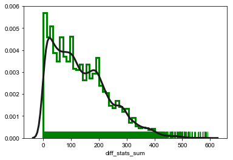

```python
cols = ["First_pokemon","Second_pokemon","Winner"]
stats_sum_dict = dict(zip(main['Number'], main['stats_sum']))
combats_stats_sum = combat[cols].replace(stats_sum_dict)
diff_stats_sum = abs(combats_stats_sum["First_pokemon"]-combats_stats_sum["Second_pokemon"])
#print(diff_stats_sum.describe())
sns.distplot(diff_stats_sum,rug=True,rug_kws={"color": "g"},kde_kws={"color": "k", "lw": 3},hist_kws={"histtype": "step", "linewidth": 3,"alpha": 1, "color": "g"})
sns.set(rc={'figure.figsize':(15,10)})
plt.xlabel("diff_stats_sum")
plt.show()
```

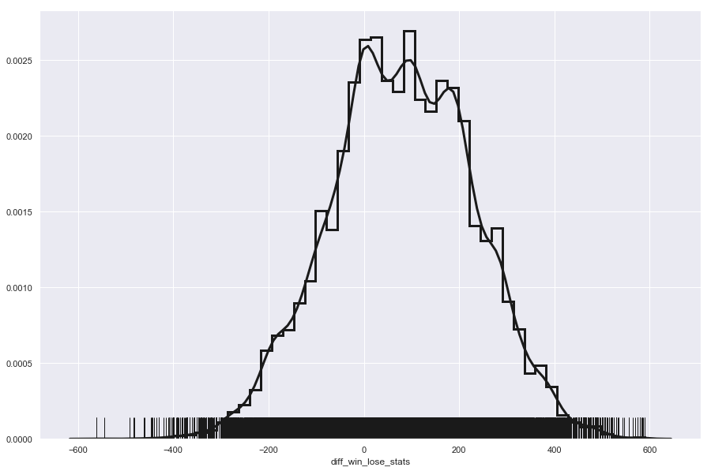

```python
combats_stats_sum["Loser"] = combats_stats_sum.apply(lambda x: x["First_pokemon"] if x["First_pokemon"] !=  x["Winner"] else x["Second_pokemon"], axis = 1)
diff_win_lose_stats = combats_stats_sum["Winner"] - combats_stats_sum["Loser"]
# print(diff_win_lose_stats.describe())
sns.distplot(diff_win_lose_stats,rug=True,rug_kws={"color": "k"},kde_kws={"color": "k", "lw": 3},hist_kws={"histtype": "step", "linewidth": 3,"alpha": 1, "color": "k"})
sns.set(rc={'figure.figsize':(15,10)})
plt.xlabel("diff_win_lose_stats")
plt.show()
```

##### From the above distribution graphs, we observe the following:

- There is a distinct difference between the trend in the graphs. The spread for diff_win_lose_stats is normally distributed whereas, that for diff_stats_sum is right skewed.
- This implies that the winning pokemon does not always have higher points. This can be observed from the diff_win_lose_stats where there are negative points capured.
- However, majority of the winning pokemons have higher points than the losing pokemons. This indicates that not al attributes considered in stats_sum are significant in determining the probability of winning of any pokemon.
- So, now we analyze the attributes that are most important in doing so.

### Assumption2: the winning probability would be affected by specific stats.( Attack, Defense...)

##### We find the top 20 pokemons with the highest winning percentage and analyze their attributes to determine which of them contribute to the higher probability of winning.

```python
strong=main.sort_values(by = ['Win Percentage'], ascending = False ).head(20)
strong.head()
```

|  | Unnamed: 0 | Number | Name | Type 1 | Type 2 | HP | Attack | Defense | Sp. Atk | Sp. Def | Speed | Generation | Legendary | Defense_adj | SpDef_adj | HP_adj | Phy_Damage_adj | Sp_Damage_adj | Win Percentage | stats_sum |
| --- | --- | --- | --- | --- | --- | --- | --- | --- | --- | --- | --- | --- | --- | --- | --- | --- | --- | --- | --- | --- |
| 154 | 154 | 155 | Mega Aerodactyl | Rock | Flying | 80 | 135 | 85 | 70 | 95 | 150 | 1 | False | 6800 | 7600 | 14400 | 24300.0 | 9450.0 | 0.984496 | 615 |
| 512 | 512 | 513 | Weavile | Dark | Ice | 70 | 120 | 65 | 45 | 85 | 125 | 4 | False | 4550 | 5950 | 10500 | 18000.0 | 6075.0 | 0.974790 | 510 |
| 703 | 703 | 704 | Tornadus Therian Forme | Flying | NaN | 79 | 100 | 80 | 110 | 90 | 121 | 5 | True | 6320 | 7110 | 13430 | 0.0 | 0.0 | 0.968000 | 580 |
| 19 | 19 | 20 | Mega Beedrill | Bug | Poison | 65 | 150 | 40 | 15 | 80 | 145 | 1 | False | 2600 | 5200 | 7800 | 20250.0 | 3000.0 | 0.966387 | 495 |
| 153 | 153 | 154 | Aerodactyl | Rock | Flying | 80 | 105 | 65 | 60 | 75 | 130 | 1 | False | 5200 | 6000 | 11200 | 18900.0 | 8100.0 | 0.964539 | 515 |

##### We create a radar chart of the averge of 6 attributes namely, HP, Attack, Defense, Sp. Atk, Sp. Def and Speed to compare between the top 20 pokemons and all pokemons. This will help to identify difference between attributes for all pokemons opposed to top 20.

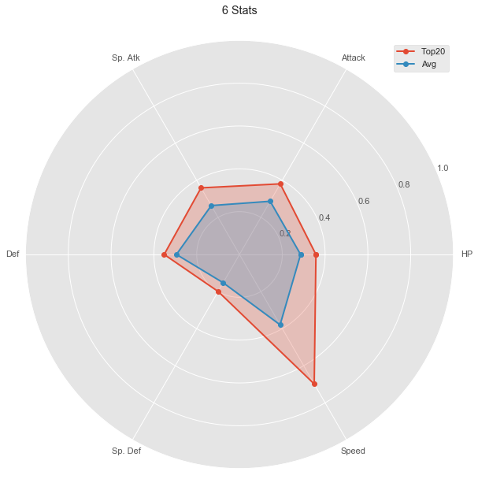

```python
plt.style.use('ggplot')

values = [strong['HP_adj'].mean()/max(main['HP_adj']),strong['Phy_Damage_adj'].mean()/max(main['Phy_Damage_adj']),strong['Sp_Damage_adj'].mean()/max(main['Sp_Damage_adj']),strong['Defense_adj'].mean()/max(main['Defense_adj']),strong['SpDef_adj'].mean()/max(main['SpDef_adj']),strong['Speed'].mean()/max(main['Speed'])]

values2=[main['HP_adj'].mean()/max(main['HP_adj']),main['Phy_Damage_adj'].mean()/max(main['Phy_Damage_adj']),main['Sp_Damage_adj'].mean()/max(main['Sp_Damage_adj']),main['Defense_adj'].mean()/max(main['Defense_adj']),main['SpDef_adj'].mean()/max(main['SpDef_adj']),main['Speed'].mean()/max(main['Speed'])]

feature = ['HP','Attack','Sp. Atk','Def','Sp. Def', 'Speed']

N = len(values)

angles=np.linspace(0, 2*np.pi, N, endpoint=False)

N = len(values)

angles=np.linspace(0, 2*np.pi, N, endpoint=False)

values=np.concatenate((values,[values[0]]))

values2=np.concatenate((values2,[values2[0]]))

angles=np.concatenate((angles,[angles[0]]))

fig=plt.figure()

ax = fig.add_subplot(111, polar=True)

ax.plot(angles, values, 'o-', linewidth=2, label= 'Top20')

ax.fill(angles, values, alpha=0.25)

ax.plot(angles, values2, 'o-', linewidth=2, label= 'Avg')

ax.fill(angles, values2, alpha=0.25)

ax.set_thetagrids(angles * 180/np.pi, feature)

ax.set_ylim(0,1)

plt.title('6 Stats')

ax.grid(True)

plt.legend(loc = 'best')

plt.show()
```

##### We now observe that Speed shows a clear difference between the average of attributes for al pokemons against top 20. Hence, Speed is definitely a significant factor in determining which pokemon wins.

##### To dig deeper, we find a correlation between all 6 attributes using a pairplot.

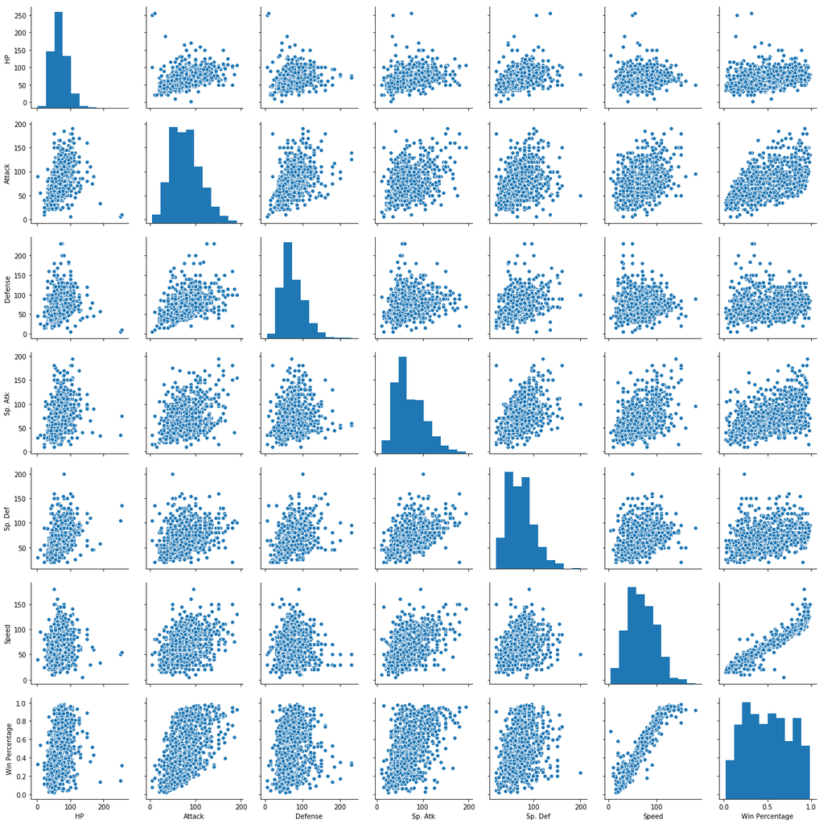

```python
col = ['Type 1','HP', 'Attack', 'Defense', 'Sp. Atk', 'Sp. Def', 'Speed', 'Win Percentage']
sns.pairplot(main.loc[:,col].dropna())
```

- As we observe, the relationship between "Speed" and "Win Percentage" is very clear and shows a distinct linear relation. Higher the speed, higher is the win precentage.
- Other than that, other attributes that show a somewhat linear relation with "Win Percentage" are Attack and Sp. Atk which can be considered for determining the winning pokemon, if not as significant as "Speed".

### Modeling

```python
df = main.drop(columns = ['Unnamed: 0', 'Number'])
```

```python
df.head()
```

|  | Name | Type 1 | Type 2 | HP | Attack | Defense | Sp. Atk | Sp. Def | Speed | Generation | Legendary | Defense_adj | SpDef_adj | HP_adj | Phy_Damage_adj | Sp_Damage_adj | Win Percentage | stats_sum |
| --- | --- | --- | --- | --- | --- | --- | --- | --- | --- | --- | --- | --- | --- | --- | --- | --- | --- | --- |
| 0 | Bulbasaur | Grass | Poison | 45 | 49 | 49 | 65 | 65 | 45 | 1 | False | 2205 | 2925 | 5130 | 6370.0 | 13000.0 | 0.278195 | 318 |
| 1 | Ivysaur | Grass | Poison | 60 | 62 | 63 | 80 | 80 | 60 | 1 | False | 3780 | 4800 | 8580 | 8060.0 | 16000.0 | 0.380165 | 405 |
| 2 | Venusaur | Grass | Poison | 80 | 82 | 83 | 100 | 100 | 80 | 1 | False | 6640 | 8000 | 14640 | 11070.0 | 20000.0 | 0.674242 | 525 |
| 3 | Mega Venusaur | Grass | Poison | 80 | 100 | 123 | 122 | 120 | 80 | 1 | False | 9840 | 9600 | 19440 | 13500.0 | 24400.0 | 0.560000 | 625 |
| 4 | Charmander | Fire | NaN | 39 | 52 | 43 | 60 | 50 | 65 | 1 | False | 1677 | 1950 | 3627 | 7800.0 | 7020.0 | 0.491071 | 309 |

Since, there are several pokemons with just one type as seen earlier, we fill the missing values in Type 2 with 'None' to maintain a clean dataset.

K-Means takes in only numerical values as input as it works basically on the concept of distance (predominantly euclidean) between data points and clusters, hence we create a separate dataframe comprising only numerical values as below:

```python
df_kmeans = df[['stats_sum','HP','Attack','Defense','Sp. Atk','Sp. Def','Speed']]
```

Now, we scale the selected numerical columns to maintain consistency in the range of variables selected.

```python
sc_X = StandardScaler()
df_kmeans = sc_X.fit_transform(df_kmeans)
```

```python
df_km = df.copy()
df_km[['Total','HP','Attack','Defense','Sp. Atk','Sp. Def','Speed']] = df_kmeans
```

In order to select the number of clusters to be formed, we take the help of elbow method that plots the Within-Cluster Sums of Squares (WCSS) against the Number of clusters and select number of clusters around which drop in WCSS as clusters increase reduces to ensure formation of meaningful clusters.

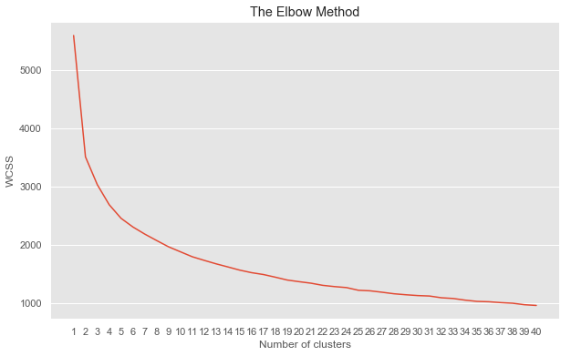

```python
within_cluster_ss = []
for i in range(1, 41):
    kmeans = KMeans(n_clusters = i, init = 'k-means++', random_state = 42)
    kmeans.fit(df_kmeans)
    within_cluster_ss.append(kmeans.inertia_)
plt.figure(figsize=(10,6))
plt.plot(range(1, 41), within_cluster_ss)
plt.title('The Elbow Method')
plt.xlabel('Number of clusters')
plt.ylabel('WCSS')
plt.xticks(np.arange(1, 41, 1.0))
plt.grid(which='major', axis='x')
plt.show()
```

Considering the relative drop in WCSS, we select 3 clusters and get y_kmeans as the last column i.e. the cluster to which each Pokemon belongs to.

```python
kmeans = KMeans(n_clusters = 3, init = 'k-means++', random_state = 42)
Clusters = kmeans.fit_predict(df_kmeans)
```

```python
df['Clusters'] = Clusters
df.head()
```

|  | Name | Type 1 | Type 2 | HP | Attack | Defense | Sp. Atk | Sp. Def | Speed | Generation | Legendary | Defense_adj | SpDef_adj | HP_adj | Phy_Damage_adj | Sp_Damage_adj | Win Percentage | stats_sum | Clusters |
| --- | --- | --- | --- | --- | --- | --- | --- | --- | --- | --- | --- | --- | --- | --- | --- | --- | --- | --- | --- |
| 0 | Bulbasaur | Grass | Poison | 45 | 49 | 49 | 65 | 65 | 45 | 1 | False | 2205 | 2925 | 5130 | 6370.0 | 13000.0 | 0.278195 | 318 | 0 |
| 1 | Ivysaur | Grass | Poison | 60 | 62 | 63 | 80 | 80 | 60 | 1 | False | 3780 | 4800 | 8580 | 8060.0 | 16000.0 | 0.380165 | 405 | 1 |
| 2 | Venusaur | Grass | Poison | 80 | 82 | 83 | 100 | 100 | 80 | 1 | False | 6640 | 8000 | 14640 | 11070.0 | 20000.0 | 0.674242 | 525 | 1 |
| 3 | Mega Venusaur | Grass | Poison | 80 | 100 | 123 | 122 | 120 | 80 | 1 | False | 9840 | 9600 | 19440 | 13500.0 | 24400.0 | 0.560000 | 625 | 2 |
| 4 | Charmander | Fire | NaN | 39 | 52 | 43 | 60 | 50 | 65 | 1 | False | 1677 | 1950 | 3627 | 7800.0 | 7020.0 | 0.491071 | 309 | 0 |

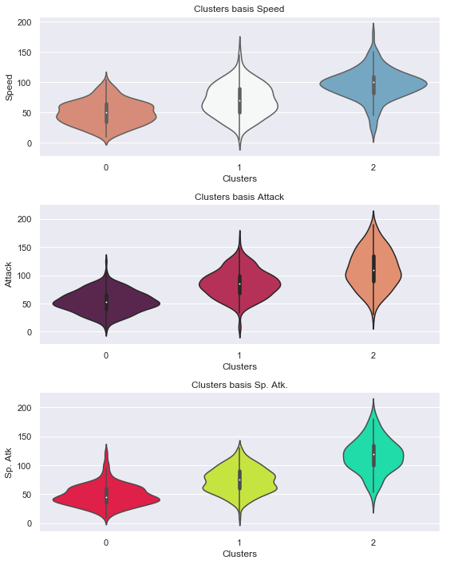

```python
sns.set(rc={'figure.figsize':(8,10)})
plt.subplot(3,1,1)
sns.violinplot(x='Clusters', y='Speed', data=df,palette='RdBu')
plt.title('Clusters basis Speed')
plt.subplot(3,1,2)
sns.violinplot(x='Clusters', y='Attack', data=df,palette='rocket')
plt.title('Clusters basis Attack')
plt.subplot(3,1,3)
sns.violinplot(x='Clusters', y='Sp. Atk', data=df,palette='gist_ncar_r')
plt.title('Clusters basis Sp. Atk.')
plt.tight_layout()
```

From the above graphs we observe that:

- The 3 clusters have distinct distributions from each other for each of the 3 attributes namely, Speed, Attack and Sp.Atk.
- However, there is a similarity in the overall statistics of the clusters, i.e. pokemons in cluster 2 have hightest stats, followed by those in cluster 1 and then in cluster 0.
- This indicates that pokemons in cluster 2 have the highest probability to win, followed by those in cluster 1 and then in cluster 0.

### Assumption3: the winning probability would be affected by types of Pokémon.

#### Firstly, we tried figuring out the type's distribution.

```python
type_cols = ["Type 1", "Type 2"]
print ("There are {} unique type-combinations.".format(len(pokemon[type_cols].drop_duplicates())))
```

```
There are 154 unique type-combinations.
```

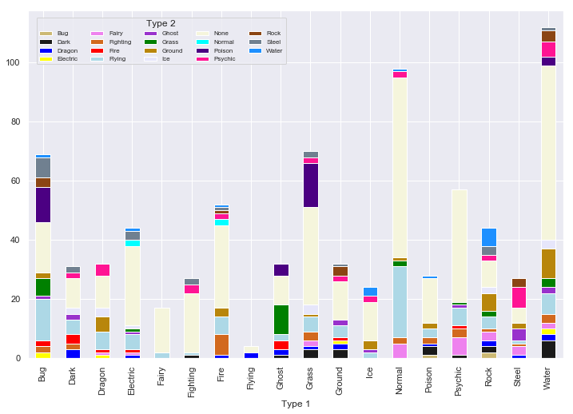

```python
pokemon["Type 2"] = pokemon["Type 2"].fillna("None")
type_cross = pd.crosstab(pokemon["Type 1"], pokemon["Type 2"])
type_cross.plot.bar(stacked=True, figsize=(12,8), color=['y','k','blue', 'yellow','violet','chocolate','red','lightblue','darkorchid',
                                                         'green','darkgoldenrod','lavender','beige','cyan','indigo','deeppink','saddlebrown','slategray','dodgerblue'])
plt.legend(bbox_to_anchor=(0.01, 0.99), loc='upper left', ncol=5, fontsize=8, title="Type 2")
# sns.palplot(sns.color_palette("Blues", 30))
plt.show()
```

##### We can see that water, normal, bug and grass are the most common type 1 and flying, ground and poison are the most common type 2. Also, there are large amount of Pokémon do not have type 2. It gives us a likelihood of battling a particular type of Pokémon and having a counter type to it. For example, since we know water Pokémon are weak against grass or electric, it might be a good idea to keep one of those types in our battle squad.

#### Secondly, we conducted winning probability comparation among various types.

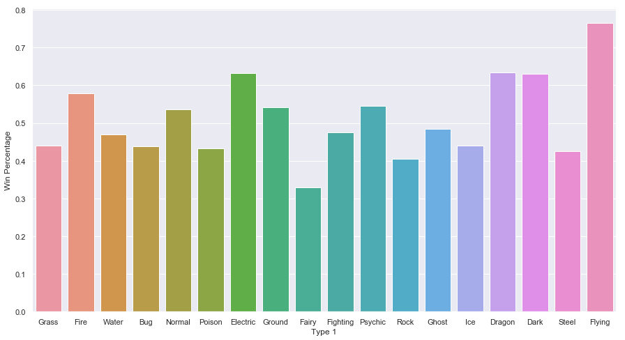

```python
plt.figure(figsize=(15,8))
ax = sns.barplot(x="Type 1", y="Win Percentage", data=main,ci=None)
```

##### From above bar charts, we could view that Pokémon with type1 being as Flying, Dragon, Dark and Electric has a higher winning probability, compared to others. Pokémon with type1 being as Fairy has the lowest winning probability.

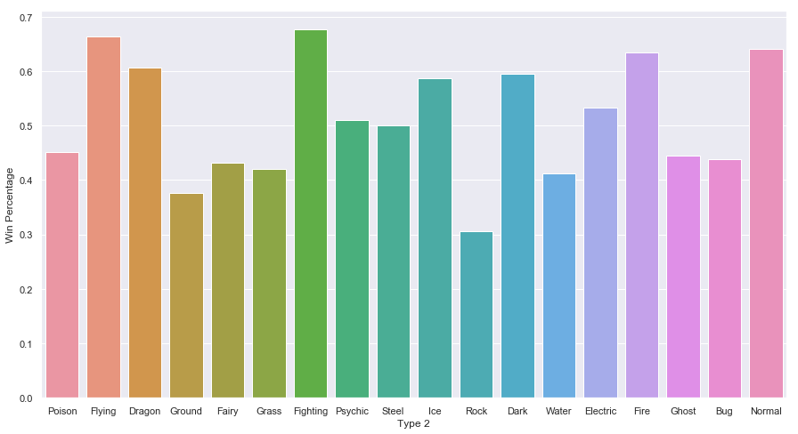

```python
plt.figure(figsize=(15,8))
ax = sns.barplot(x="Type 2", y="Win Percentage", data=main,ci=None)
```

##### Also, Pokémon with type2 being as Fighting, Flying, Normal and Fire has a higher winning probability, compared to others. Pokémon with type2 being as Rock has the lowest winning probability.

#### Thirdly, we tried identifying if the winning probability is caused by the statistical data of the types or the specific types. Below chart is built based on Top 5 types Pokémon’s data. As in the previous phase we learned Speed and attack are the most two powerful variables among the statistical data to the winning rate, in this phase, we look into the speed data and attack data for those type of Pokémon.

```python
import plotly
plotly.offline.init_notebook_mode(connected=True)
import plotly.graph_objs as go
from plotly.offline import init_notebook_mode, plot,iplot

data_water = main[main['Type 1']=='Flying']
data_grass = main[main['Type 1']=='Dragon']
data_fire = main[main['Type 1']=='Electric']
data_bug = main[main['Type 1']=='Dark']
data_psychic = main[main['Type 1']=='Fire']

box1 = go.Box(
                y= data_water.Speed,
                name= 'Flying Pokemons',
                marker = dict(color = 'rgb(12, 128, 128)'),
                boxmean='sd',
                boxpoints='all')
box2 = go.Box(
                y= data_grass.Speed,
                name= 'Dragon Pokemons',
                marker = dict(color = 'rgb(100, 12, 38)'),
                boxmean='sd',
                boxpoints='all')
box3 = go.Box(
                y= data_fire.Speed,
                name= 'Electric Pokemons',
                marker = dict(color = 'rgb(12, 128, 128)'),
                boxmean='sd',
                boxpoints='all')
box4 = go.Box(
                y= data_bug.Speed,
                name= 'Dark Pokemons',
                marker = dict(color = 'rgb(50, 40, 100)'),
                boxmean='sd',
                boxpoints='all')
box5 = go.Box(
                y= data_psychic.Speed,
                name= 'Fire Pokemons',
                marker = dict(color = 'rgb(45, 179, 66)'),
                boxmean='sd',
                boxpoints='all')

data_boxes = [box1,box2,box3,box4,box5]
iplot(data_boxes)
```

[interactive chart not shown]

##### From above chart made by Top 5 types’ Pokémon’s speed data, we could view that flying actually has the highest speed distribution compared to others. The findings might help to explain why the Pokémon with type being flying for either type 1 and type 2 has a higher winning probability. While, considering the speed amount only could not provide enough support for the winning rate various for the others.

```python
import plotly
plotly.offline.init_notebook_mode(connected=True)
import plotly.graph_objs as go
from plotly.offline import init_notebook_mode, plot,iplot

data_water = main[main['Type 1']=='Flying']
data_grass = main[main['Type 1']=='Dragon']
data_fire = main[main['Type 1']=='Electric']
data_bug = main[main['Type 1']=='Dark']
data_psychic = main[main['Type 1']=='Fire']

box1 = go.Box(
                y= data_water.Attack,
                name= 'Flying Pokemons',
                marker = dict(color = 'rgb(12, 128, 128)'),
                boxmean='sd',
                boxpoints='all')
box2 = go.Box(
                y= data_grass.Attack,
                name= 'Dragon Pokemons',
                marker = dict(color = 'rgb(100, 12, 38)'),
                boxmean='sd',
                boxpoints='all')
box3 = go.Box(
                y= data_fire.Attack,
                name= 'Electric Pokemons',
                marker = dict(color = 'rgb(12, 128, 128)'),
                boxmean='sd',
                boxpoints='all')
box4 = go.Box(
                y= data_bug.Attack,
                name= 'Dark Pokemons',
                marker = dict(color = 'rgb(50, 40, 100)'),
                boxmean='sd',
                boxpoints='all')
box5 = go.Box(
                y= data_psychic.Attack,
                name= 'Fire Pokemons',
                marker = dict(color = 'rgb(45, 179, 66)'),
                boxmean='sd',
                boxpoints='all')

data_boxes = [box1,box2,box3,box4,box5]
iplot(data_boxes)
```

[interactive chart not shown]

##### Also, from the above chart made by Top 5 types’ Pokémon’s attack data, we could view that attack amount did not have any dominant effect on the various types’ winning rate. To be specific, flying Pokémon has a much higher winning rate compared to dragon Pokémon, even though its attack data is far below dragon’s.

### Assumption4: there are some specific Pokémon which have very high or low winning probability, regardless their score, status or type.

#### We looked into the special cases in which the “seems” weak Pokémon actually won the “strong” one, and found that within 50,000 combats, there are about 5716 ones in which the “seems” weak Pokémon actually won the “strong” one, with the scores for the "weak" one being at least 100 less than compared to the "strong" one.

```python
names_dict = dict(zip(pokemon['Number'], pokemon['Name']))
stats_sum_dict_re = (zip(pokemon['stats_sum'], pokemon['Number']))
combats_stats_sum["diff"] = diff_win_lose_stats
surpassing_stats_sum = combats_stats_sum[combats_stats_sum["diff"] < -100]
print ("Surpassing one's superiors Battle number : " + str(len(surpassing_stats_sum)))
```

```
Surpassing one's superiors Battle number : 5716
```

#### Firstly, we looked in the name of the winners. “Mega” appears a lot in the winners’ name.

```
Mewtwo                152
Infernape             136
Aerodactyl            136
Jirachi               134
Slaking               133
Deoxys Speed Forme    133
Mega Absol            130
Murkrow               130
Mega Houndoom         128
Mega Rayquaza         127
Name: Winner, dtype: int64
```

[figure not shown]

```python
import numpy as np
from wordcloud import WordCloud, ImageColorGenerator
from PIL import Image

combats_names = combat[cols].replace(names_dict)
print (combats_names["Winner"].value_counts()[:10])
winners = list(combats_names["Winner"])
winners_str = [str(i) for i in winners]
winners_text = (",").join(winners_str)
wc = WordCloud(background_color= "black", random_state=1, margin=3).generate(winners_text)
plt.figure(figsize=(10,10))
plt.axis("off")
plt.imshow(wc, interpolation='bilinear')
plt.show()
```

#### Secondly, by looking in the special case, “Shedinja” actually could win “Mega Rayquaza” , even though “Shedinja” seems weaker than most Pokémon, and “Mega Rayquaza” seems have more power than others.

```python
names_dict = dict(zip(pokemon['Number'], pokemon['Name']))
stats_sum_dict_re = dict(zip(pokemon['stats_sum'], pokemon['Number']))
combats_stats_sum["diff"] = diff_win_lose_stats
surpassing_stats_sum = combats_stats_sum[combats_stats_sum["diff"] < -100]
surpassing_id = surpassing_stats_sum[cols].replace(stats_sum_dict_re)
surpassing_name = surpassing_id[cols].replace(names_dict)
```

```python
surpassing_name.join(combats_stats_sum["diff"]).sort_values(by="diff").head()
```

|  | First_pokemon | Second_pokemon | Winner | diff |
| --- | --- | --- | --- | --- |
| 5861 | Mega Rayquaza | Cleffa | Cleffa | -562 |
| 2480 | Mega Rayquaza | Cleffa | Cleffa | -562 |
| 41824 | Shedinja | Mega Rayquaza | Shedinja | -544 |
| 3506 | Mega Rayquaza | Inkay | Inkay | -492 |
| 20527 | Arceus | Shedinja | Shedinja | -484 |

[figure not shown]

#### Thirdly, within these 50,000 combats, “Shuckle” won none of them. That might suggest that the player should better to avoid “Shuckle” if they want to win the game.

```python
first_num = combats_names["First_pokemon"].value_counts()
second_num = combats_names["Second_pokemon"].value_counts()
battle_num = first_num + second_num
battle_win = pd.DataFrame({"battle": battle_num, "win": combats_names["Winner"].value_counts()}, columns=["battle", "win"])
battle_win["ratio"] = battle_win["win"]/battle_win["battle"]
battle_win[battle_win["win"].isnull()]
```

|  | battle | win | ratio |
| --- | --- | --- | --- |
| Shuckle | 135 | NaN | NaN |

[figure not shown]

## Insights

1. Base stats of pokemons matter during a battle, predominantly Speed. Also, Attack and Sp. Atk. are other stats that could be considered while choosing a pokemon.
2. Choosing a Mega evolution pokemon can be advantageous as they have higher probabilities of winning.
3. Pokemon is a game with data, not a game of data. All those data can help you win the game but cannot guarantee that. With a deliberate strategy, even a pokemon with only 1 HP can beat the Mega-evolution Legendary pokemon.

## Phase 3: Simulation

According to our findings above, we choose 3 pokemons: Aerodactyl, Greninja, Mega Sceptile.  
And we have 2018 pokemon world championship's team: Gastrodon, Salamence, Snorlax.  
We choose pokemon's most commonly used moves(https://boe2.github.io/bsus.html), and simulate their battles.

1. Load the dataset.

```python
pokemon=pd.read_csv('pokemon.csv')
pokemove=pd.read_csv('All moves.csv')
typechart=pd.read_csv('pokemon/typechart.csv')
```

1. Set two tokens that we will use later

```python
token = {'name':'token','type1':None, 'type2':None,
         'hp':0,
         'atk':0,
         'defe':0,
         'spatk':0,
         'spdefe':0,
         'sp':0,
         'move0': None,
         'move1': None,
         'move2': None,
         'move3': None,
         'move4': None}
mtoken = {'mname': 'token',
          'mtype': 'Normal',
          'mcate':0,
          'mpower':0,
          'macc':0}
```

Define some functions that we will use later.

```python
#get information function
# This function can get us the information of moves
def get_move(i):
    move = {'mname': i,
               'mtype':pokemove.loc[pokemove['Name']==i,'Type'].item(),
                'mcate':pokemove.loc[pokemove['Name']==i,'Category'].item(),
                'mpower':pokemove.loc[pokemove['Name']==i,'Power'].item(),
                'macc':pokemove.loc[pokemove['Name']==i,'Accuracy'].item()}
    return move
# This function can get us the information of pokemon
def get_pokemon(i):
    if ('Mega' in i):
        pokeinfo = {'name': i,
         'type1':pokemon.loc[pokemon['Name'].str.contains(i),'Type 1'].item(), 'type2':pokemon.loc[pokemon['Name'].str.contains(i),'Type 2'].item(),
         'hp':(pokemon.loc[pokemon['Name'].str.contains(i),'HP'].item()*2+31)*50/100+10+50,
         'atk':(pokemon.loc[pokemon['Name'].str.contains(i),'Attack'].item()*2+31)*50/100+5,
         'defe':(pokemon.loc[pokemon['Name'].str.contains(i),'Defense'].item()*2+31)*50/100+5,
         'spatk':(pokemon.loc[pokemon['Name'].str.contains(i),'Sp. Atk'].item()*2+31)*50/100+5,
         'spdefe':(pokemon.loc[pokemon['Name'].str.contains(i),'Sp. Def'].item()*2+31)*50/100+5,
         'sp':(pokemon.loc[pokemon['Name'].str.contains(i),'Speed']*2+31).item()*50/100+5,
         'move0': None,
         'move1': None,
         'move2': None,
         'move3': None,
         'move4': None}
    else:
        pokeinfo = {'name': i,
             'type1':pokemon.loc[pokemon['Name']==i,'Type 1'].item(), 'type2':pokemon.loc[pokemon['Name']==i,'Type 2'].item(),
             'hp':(pokemon.loc[pokemon['Name']==i,'HP'].item()*2+31)*50/100+10+50,
             'atk':(pokemon.loc[pokemon['Name']==i,'Attack'].item()*2+31)*50/100+5,
             'defe':(pokemon.loc[pokemon['Name']==i,'Defense'].item()*2+31)*50/100+5,
             'spatk':(pokemon.loc[pokemon['Name']==i,'Sp. Atk'].item()*2+31)*50/100+5,
             'spdefe':(pokemon.loc[pokemon['Name']==i,'Sp. Def'].item()*2+31)*50/100+5,
             'sp':(pokemon.loc[pokemon['Name']==i,'Speed']*2+31).item()*50/100+5,
             'move0': None,
             'move1': None,
             'move2': None,
             'move3': None,
             'move4': None}
    return pokeinfo
```

```python
#set player's status
def setplayer(player,pokemon0):
    if player['pokemon1']['name']==pokemon0:
        player['pokemon0'],player['pokemon1'] = player['pokemon1'],player['pokemon0']
    elif player['pokemon2']['name']==pokemon0:
        player['pokemon0'],player['pokemon2'] = player['pokemon2'],player['pokemon0']
    elif player['pokemon3']['name']==pokemon0:
        player['pokemon0'],player['pokemon3'] = player['pokemon3'],player['pokemon0']
    return player
#set move's status
def setmove(pokemon,move0):
    if pokemon['move1']['mname']==move0:
        pokemon['move0']= pokemon['move1']
    elif pokemon['move2']['mname']==move0:
        pokemon['move0']= pokemon['move2']
    elif pokemon['move3']['mname']==move0:
        pokemon['move0']= pokemon['move3']
    elif pokemon['move4']['mname']==move0:
        pokemon['move0']= pokemon['move4']
    return pokemon
```

Then we define the function to calculate damage.

```python
#Hit the target or not?
def hit(move):
    if random.uniform(0,1)<=move['macc']:
        return True
    else:
        return False

#Critical Hit? When Critical hit, the damage will increase by 50%
def critical():
    return random.choice([1.5,1,1,1,1,1,1,1,1,1,1,1,1,1,1,1,1,1,1,1,1,1,1,1])

#Type is stronger against the opponent?
def modifier(type1,type2):
    try:
        return typechart.loc[typechart['attack']==type1, type2].item()
    except:
        return 1

#Damage
def damage(pokemon1,pokemon2, move):
    if hit(move):
    #Basic Damage
        damage1 = (2*50 + 10)/250*pokemon1['atk']/pokemon2['defe']*move['mpower']+2
    #Other Damages
        if move['mtype'] == pokemon1['type1'] or move['mtype'] == pokemon1['type2']:
            damage2 = 1.5 * modifier(move['mtype'],pokemon2['type1'])*modifier(move['mtype'],pokemon2['type2']) * critical() * random.uniform(0.85,1)
        else:
            damage2 = modifier(move['mtype'],pokemon2['type1'])*modifier(move['mtype'],pokemon2['type2']) * critical() * random.uniform(0.85,1)
    #Total Damage
        if damage2 == 0:
            return 0
        else:
            damage = round(damage1 * damage2)
            if damage <= 1:
                return 1
            else:
                return damage
    else:
        #print('Missed!')
        return 0
```

```python
#Which one attack first?
def p1_atkfirst():
    if playera['pokemon0']['sp']>playerb['pokemon0']['sp']:
        return True
    elif playera['pokemon0']['sp']<playerb['pokemon0']['sp']:
        return False
    else:
        if random.choice([0,1])==0:
            return True
        else:
            return False
```

```python
#Switch Pokemon
def switch(player,pokemon):
    if player['pokemon1']['name']==pokemon:
        player['pokemon0'],player['pokemon1'] = player['pokemon1'],player['pokemon0']
    elif player['pokemon2']['name']==pokemon:
        player['pokemon0'],player['pokemon2'] = player['pokemon2'],player['pokemon0']
    elif player['pokemon3']['name']==pokemon:
        player['pokemon0'],player['pokemon3'] = player['pokemon3'],player['pokemon0']
def choose_pokemon(player):
    lst=[]
    for i in [player['pokemon1'],player['pokemon2'],player['pokemon3']]:
        if i['name']!='token':
            lst.append(i['name'])
        else:
            pass
    return lst
```

Before the battle, we set up players first.

```python
#Before the battle
print ('Welcome to this game.')
#Player1
player1_name = input("enter player1 name here: ")
#Player2
player2_name = input("enter player2 name here: ")

#player1's pokemon
print('player1 choose pokemon')
a = input('pokemon1:')
b = input('pokemon2:')
c = input('pokemon3:')
p1_pokemon1 = get_pokemon(a)
p1_pokemon2= get_pokemon(b)
p1_pokemon3=get_pokemon(c)
#choose moves
for i in [p1_pokemon1,p1_pokemon2,p1_pokemon3]:
    move1name=input(str(i['name'])+'\'s move1: ')
    move2name=input(str(i['name'])+'\'s move2: ')
    move3name=input(str(i['name'])+'\'s move3: ')
    move4name=input(str(i['name'])+'\'s move4: ')
    i['move0']=mtoken
    i['move1']=get_move(move1name)
    i['move2']=get_move(move2name)
    i['move3']=get_move(move3name)
    i['move4']=get_move(move4name)
player1 = {'Name': player1_name, 'pokemon0': token, 'pokemon1': p1_pokemon1, 'pokemon2': p1_pokemon2, 'pokemon3': p1_pokemon3, 'num': 3}
#player2's pokemon
print('player2 choose pokemon')
a = input('pokemon1:')
b = input('pokemon2:')
c = input('pokemon3:')
p2_pokemon1 = get_pokemon(a)
p2_pokemon2= get_pokemon(b)
p2_pokemon3=get_pokemon(c)
#choose moves
for i in [p2_pokemon1,p2_pokemon2,p2_pokemon3]:
    move1name=input(str(i['name'])+'\'s move1: ')
    move2name=input(str(i['name'])+'\'s move2: ')
    move3name=input(str(i['name'])+'\'s move3: ')
    move4name=input(str(i['name'])+'\'s move4: ')
    i['move1']=get_move(move1name)
    i['move2']=get_move(move2name)
    i['move3']=get_move(move3name)
    i['move4']=get_move(move4name)
player2 = {'Name': player2_name, 'pokemon0': token, 'pokemon1': p1_pokemon1, 'pokemon2': p1_pokemon2, 'pokemon3': p1_pokemon3, 'num': 3}
```

```
Welcome to this game.
enter player1 name here: Jimmy
enter player2 name here: Peter
player1 choose pokemon
pokemon1:Aerodactyl
pokemon2:Greninja
pokemon3:Mega Sceptile
Aerodactyl's move1: Earthquake
Aerodactyl's move2: Ice Fang
Aerodactyl's move3: Stone Edge
Aerodactyl's move4: Iron Head
Greninja's move1: Ice Beam
Greninja's move2: Water Shuriken
Greninja's move3: Dark Pulse
Greninja's move4: Scald
Mega Sceptile's move1: Dragon Pulse
Mega Sceptile's move2: Leaf Storm
Mega Sceptile's move3: Energy Ball
Mega Sceptile's move4: Focus Blast
player2 choose pokemon
pokemon1:Gastrodon
pokemon2:Mega Salamence
pokemon3:Snorlax
Gastrodon's move1: Ice Beam
Gastrodon's move2: Scald
Gastrodon's move3: Earth Power
Gastrodon's move4: Sludge Wave
Mega Salamence's move1: Earthquake
Mega Salamence's move2: Double-Edge
Mega Salamence's move3: Fire Blast
Mega Salamence's move4: Draco Meteor
Snorlax's move1: Earthquake
Snorlax's move2: Return
Snorlax's move3: Double-Edge
Snorlax's move4: Fire Punch
```

Now we have set the players' poekmon and their moves. We will run 100 games to see which team has a higher winning probability.

```python
#Now play the game
player1_w = 0
player2_w = 0
for i in range(1,101):
    playera=player1.copy()
    playerb=player2.copy()
    a = random.choice(choose_pokemon(playera))
    playera = setplayer(playera, a)
    a = random.choice(choose_pokemon(playerb))
    playerb = setplayer(playerb, a)
    while (playera['num']>0) & (playerb['num']>0):
        try:
            b = random.choice([playera['pokemon0']['move1']['mname'],playera['pokemon0']['move2']['mname'],playera['pokemon0']['move3']['mname'],playera['pokemon0']['move4']['mname']])
            playera['pokemon0'] = setmove(playera['pokemon0'],b)
        except:
            pass
        try:
            b = random.choice([playerb['pokemon0']['move1']['mname'],playerb['pokemon0']['move2']['mname'],playerb['pokemon0']['move3']['mname'],playerb['pokemon0']['move4']['mname']])
            playerb['pokemon0'] = setmove(playerb['pokemon0'],b)
        except:
            pass
        if p1_atkfirst():
            playerb['pokemon0']['hp'] -= damage(playera['pokemon0'],playerb['pokemon0'],playera['pokemon0']['move0'])
            if playerb['pokemon0']['hp']<=0:
                playerb['pokemon0']=token
            #player2['pokemon0']['name']+ ' cannot fight anymore!'
                playerb['num']-=1
                if playerb['num']<=0:
                #'Game over: '+player1['Name']+' wins!'
                    player1_w += 1
                else:
                    nextp = random.choice(choose_pokemon(playerb))
                    playerb = setplayer(playerb,nextp)
            else:
                playera['pokemon0']['hp'] -= damage(playerb['pokemon0'],playera['pokemon0'],playerb['pokemon0']['move0'])
                if playera['pokemon0']['hp']<=0:
                    playera['pokemon0']=token
                #player1['pokemon0']['name']+ ' cannot fight anymore!'
                    playera['num']-=1
                    if playera['num']<=0:
                    #'Game over: '+player1['Name']+' wins!'
                        player2_w += 1
                    else:
                        nextp = random.choice(choose_pokemon(playera))
                        playera = setplayer(playera,nextp)
        else:
            playera['pokemon0']['hp'] -= damage(playerb['pokemon0'],playera['pokemon0'],playerb['pokemon0']['move0'])
            if playera['pokemon0']['hp']<=0:
                playera['pokemon0']=token
            #player1['pokemon0']['name']+ ' cannot fight anymore!'
                playera['num']-=1
                if playera['num']<=0:
                #'Game over: '+player1['Name']+' wins!'
                    player2_w += 1
                else:
                    nextp = random.choice(choose_pokemon(playera))
                    playera = setplayer(playera,nextp)
            else:
                playerb['pokemon0']['hp'] -= damage(playera['pokemon0'],playerb['pokemon0'],playera['pokemon0']['move0'])
                if playerb['pokemon0']['hp']<=0:
                    playerb['pokemon0']=token
                #player2['pokemon0']['name']+ ' cannot fight anymore!'
                    playerb['num']-=1
                    if playerb['num']<=0:
                    #'Game over: '+player1['Name']+' wins!'
                        player1_w += 1
                    else:
                        nextp = random.choice(choose_pokemon(playerb))
                        playerb = setplayer(playerb,nextp)
print('Player 1 vs Player 2 ' + str(player1_w)+':'+str(player2_w))
```

```
Player 1 vs Player 2 59:41
```

## Conclusion

Pokémon is a global icon to children and adults everywhere. It is a TV series that has expanded into video games, card games, movies, merchandise and everything in between. The motivation behind this analysis is to further understand the dynamics of the Pokémon universe through data, and try providing some overview understanding and strategies to new players of Pokémon games.

This project looked into the Pokémon overview (e.g. Pokémon types' distribution), which gives the big picture in term of Type flavor, and specific Pokémon Characteristics (e.g. Top 5 types' Pokémon’s speed data) by using below four assumptions as the storyline.

- Assumption1: the winning probability would be affected by total points.
- Assumption2: the winning probability would be affected by specific stats (Attack, Defense, Defense, Atk_Spd, Atk_Def, HP).
- Assumption3: the winning probability would be affected by types of Pokémon.
- Assumption4: there are some specific Pokémon which have very high or low winning probability, regardless their score, status or type.

Based on the findings in data analysis phase, we learned that,

- For assumption1, we found that the winning Pokémon does not always have higher points. However, majority of the winning Pokémon have higher points than the losing Pokémon.
- For assumption2, we found that speed and attack are the top 2 significant factors in determining which Pokémon wins.
- For assumption3, we found that Pokémon with type1 being as Flying, Dragon, Dark and Electric has a higher winning probability, and Pokémon with type2 being as Fighting, Flying, Normal and Fire has a higher winning probability, compared to others.
- For assumption4, we found that “Mega” appears a lot in the winners’ name, and “Shuckle” won none of them in 50000 combats.

The findings would be very helpful for new Pokémon players, because it gives some clear clues about which Pokémon to be chosen to avoid very frustrating results at the beginning. Also, from the findings, we could also understand why Pokémon games appeals to such large amount of players. It is a game with data, but not a game of data. A good Pokémon means a high winning probability, but not guarantee the winning result.

[figure not shown]